# Part I - Exploration of Fordgobike 2019 data

## Introduction

> - This dataset includes information about individual rides made in a bike-sharing system covering the greater San Francisco Bay area.
> - The dataset has 183412 values and 16 variables . The variables in the dataset include: `duration_sec` `start_time` `end_time` `start_station_id` `start_station_name` `start_station_latitude` `start_station_longitude` `end_station_id` `end_station_name` `end_station_latitude` `end_station_longitude` `bike_id` `user_type` `member_birth_year` `member_gender` `bike_share_for_all_trip`

## Preliminary Wrangling

```python
# import all packages and set plots to be embedded inline
import numpy as np
import pandas as pd
import matplotlib.pyplot as plt
import seaborn as sb
import time
import datetime
import calendar
import warnings

%matplotlib inline

#suppress warnings from final output
warnings.simplefilter("ignore")
```

> Load in your dataset and describe its properties through the questions below. Try and motivate your exploration goals through this section.

```python
#load dataset
df = pd.read_csv('201902-fordgobike-tripdata.csv')
```

```python
#checking top 5 rows
df.head()
```

|  | duration_sec | start_time | end_time | start_station_id | start_station_name | start_station_latitude | start_station_longitude | end_station_id | end_station_name | end_station_latitude | end_station_longitude | bike_id | user_type | member_birth_year | member_gender | bike_share_for_all_trip |
| --- | --- | --- | --- | --- | --- | --- | --- | --- | --- | --- | --- | --- | --- | --- | --- | --- |
| 0 | 52185 | 2019-02-28 17:32:10.1450 | 2019-03-01 08:01:55.9750 | 21.0 | Montgomery St BART Station (Market St at 2nd St) | 37.789625 | -122.400811 | 13.0 | Commercial St at Montgomery St | 37.794231 | -122.402923 | 4902 | Customer | 1984.0 | Male | No |
| 1 | 42521 | 2019-02-28 18:53:21.7890 | 2019-03-01 06:42:03.0560 | 23.0 | The Embarcadero at Steuart St | 37.791464 | -122.391034 | 81.0 | Berry St at 4th St | 37.775880 | -122.393170 | 2535 | Customer | NaN | NaN | No |
| 2 | 61854 | 2019-02-28 12:13:13.2180 | 2019-03-01 05:24:08.1460 | 86.0 | Market St at Dolores St | 37.769305 | -122.426826 | 3.0 | Powell St BART Station (Market St at 4th St) | 37.786375 | -122.404904 | 5905 | Customer | 1972.0 | Male | No |
| 3 | 36490 | 2019-02-28 17:54:26.0100 | 2019-03-01 04:02:36.8420 | 375.0 | Grove St at Masonic Ave | 37.774836 | -122.446546 | 70.0 | Central Ave at Fell St | 37.773311 | -122.444293 | 6638 | Subscriber | 1989.0 | Other | No |
| 4 | 1585 | 2019-02-28 23:54:18.5490 | 2019-03-01 00:20:44.0740 | 7.0 | Frank H Ogawa Plaza | 37.804562 | -122.271738 | 222.0 | 10th Ave at E 15th St | 37.792714 | -122.248780 | 4898 | Subscriber | 1974.0 | Male | Yes |

```python
#checkin the last 5 rows
df.tail()
```

|  | duration_sec | start_time | end_time | start_station_id | start_station_name | start_station_latitude | start_station_longitude | end_station_id | end_station_name | end_station_latitude | end_station_longitude | bike_id | user_type | member_birth_year | member_gender | bike_share_for_all_trip |
| --- | --- | --- | --- | --- | --- | --- | --- | --- | --- | --- | --- | --- | --- | --- | --- | --- |
| 183407 | 480 | 2019-02-01 00:04:49.7240 | 2019-02-01 00:12:50.0340 | 27.0 | Beale St at Harrison St | 37.788059 | -122.391865 | 324.0 | Union Square (Powell St at Post St) | 37.788300 | -122.408531 | 4832 | Subscriber | 1996.0 | Male | No |
| 183408 | 313 | 2019-02-01 00:05:34.7440 | 2019-02-01 00:10:48.5020 | 21.0 | Montgomery St BART Station (Market St at 2nd St) | 37.789625 | -122.400811 | 66.0 | 3rd St at Townsend St | 37.778742 | -122.392741 | 4960 | Subscriber | 1984.0 | Male | No |
| 183409 | 141 | 2019-02-01 00:06:05.5490 | 2019-02-01 00:08:27.2200 | 278.0 | The Alameda at Bush St | 37.331932 | -121.904888 | 277.0 | Morrison Ave at Julian St | 37.333658 | -121.908586 | 3824 | Subscriber | 1990.0 | Male | Yes |
| 183410 | 139 | 2019-02-01 00:05:34.3600 | 2019-02-01 00:07:54.2870 | 220.0 | San Pablo Ave at MLK Jr Way | 37.811351 | -122.273422 | 216.0 | San Pablo Ave at 27th St | 37.817827 | -122.275698 | 5095 | Subscriber | 1988.0 | Male | No |
| 183411 | 271 | 2019-02-01 00:00:20.6360 | 2019-02-01 00:04:52.0580 | 24.0 | Spear St at Folsom St | 37.789677 | -122.390428 | 37.0 | 2nd St at Folsom St | 37.785000 | -122.395936 | 1057 | Subscriber | 1989.0 | Male | No |

```python
#number of rows and columns
df.shape
```

```
(183412, 16)
```

```python
#print concise summary of the dataframe
#getting variable data types, number of rows and columns and full name of variables
df.info()
```

```
<class 'pandas.core.frame.DataFrame'>
RangeIndex: 183412 entries, 0 to 183411
Data columns (total 16 columns):
 #   Column                   Non-Null Count   Dtype
---  ------                   --------------   -----
 0   duration_sec             183412 non-null  int64
 1   start_time               183412 non-null  object
 2   end_time                 183412 non-null  object
 3   start_station_id         183215 non-null  float64
 4   start_station_name       183215 non-null  object
 5   start_station_latitude   183412 non-null  float64
 6   start_station_longitude  183412 non-null  float64
 7   end_station_id           183215 non-null  float64
 8   end_station_name         183215 non-null  object
 9   end_station_latitude     183412 non-null  float64
 10  end_station_longitude    183412 non-null  float64
 11  bike_id                  183412 non-null  int64
 12  user_type                183412 non-null  object
 13  member_birth_year        175147 non-null  float64
 14  member_gender            175147 non-null  object
 15  bike_share_for_all_trip  183412 non-null  object
dtypes: float64(7), int64(2), object(7)
memory usage: 22.4+ MB
```

> The time data types: `start_time` and `end_time` should be datetimestamp data types `start_station_id`, `end_station_id` and `bike_id` should be str data type `member_birth_year` sould be int data type.

```python
#get random sample of the data
df.sample(10)
```

|  | duration_sec | start_time | end_time | start_station_id | start_station_name | start_station_latitude | start_station_longitude | end_station_id | end_station_name | end_station_latitude | end_station_longitude | bike_id | user_type | member_birth_year | member_gender | bike_share_for_all_trip |
| --- | --- | --- | --- | --- | --- | --- | --- | --- | --- | --- | --- | --- | --- | --- | --- | --- |
| 97572 | 1131 | 2019-02-15 08:38:16.9590 | 2019-02-15 08:57:08.2590 | 15.0 | San Francisco Ferry Building (Harry Bridges Pl... | 37.795392 | -122.394203 | 92.0 | Mission Bay Kids Park | 37.772301 | -122.393028 | 4778 | Subscriber | 1991.0 | Female | No |
| 165826 | 295 | 2019-02-04 21:59:34.8150 | 2019-02-04 22:04:30.4130 | 158.0 | Shattuck Ave at Telegraph Ave | 37.833279 | -122.263490 | 204.0 | 55th St at Telegraph Ave | 37.840186 | -122.261822 | 5391 | Subscriber | 1986.0 | Male | No |
| 164586 | 427 | 2019-02-05 08:20:10.1900 | 2019-02-05 08:27:17.2810 | 44.0 | Civic Center/UN Plaza BART Station (Market St ... | 37.781074 | -122.411738 | 284.0 | Yerba Buena Center for the Arts (Howard St at ... | 37.784872 | -122.400876 | 4995 | Subscriber | 1984.0 | Male | No |
| 174089 | 526 | 2019-02-02 23:02:24.4610 | 2019-02-02 23:11:10.7430 | 43.0 | San Francisco Public Library (Grove St at Hyde... | 37.778768 | -122.415929 | 85.0 | Church St at Duboce Ave | 37.770083 | -122.429156 | 4995 | Subscriber | 1968.0 | Male | No |
| 148681 | 470 | 2019-02-06 21:04:18.3110 | 2019-02-06 21:12:08.4970 | 77.0 | 11th St at Natoma St | 37.773507 | -122.416040 | 67.0 | San Francisco Caltrain Station 2 (Townsend St... | 37.776639 | -122.395526 | 5358 | Subscriber | 1992.0 | Male | No |
| 69001 | 407 | 2019-02-19 20:31:40.0450 | 2019-02-19 20:38:27.1330 | 385.0 | Woolsey St at Sacramento St | 37.850578 | -122.278175 | 169.0 | Bushrod Park | 37.846516 | -122.265304 | 4765 | Subscriber | 1997.0 | Male | No |
| 160125 | 881 | 2019-02-05 17:14:18.3510 | 2019-02-05 17:28:59.3520 | 70.0 | Central Ave at Fell St | 37.773311 | -122.444293 | 58.0 | Market St at 10th St | 37.776619 | -122.417385 | 5004 | Subscriber | 1981.0 | Female | No |
| 25085 | 423 | 2019-02-25 17:28:24.6170 | 2019-02-25 17:35:28.2810 | 114.0 | Rhode Island St at 17th St | 37.764478 | -122.402570 | 80.0 | Townsend St at 5th St | 37.775235 | -122.397437 | 1469 | Subscriber | 1981.0 | Male | No |
| 69239 | 575 | 2019-02-19 19:53:23.4940 | 2019-02-19 20:02:59.1940 | 126.0 | Esprit Park | 37.761634 | -122.390648 | 129.0 | Harrison St at 20th St | 37.758862 | -122.412544 | 4615 | Subscriber | 1972.0 | Male | No |
| 142036 | 237 | 2019-02-07 17:32:19.9390 | 2019-02-07 17:36:17.5580 | 270.0 | Ninth St at Heinz Ave | 37.853489 | -122.289415 | 157.0 | 65th St at Hollis St | 37.846784 | -122.291376 | 5102 | Subscriber | 1983.0 | Male | No |

```python
#sum of duplicates
df.duplicated().sum()
```

```
0
```

```python
#sum of null values
df.isnull().sum()
```

```
duration_sec                  0
start_time                    0
end_time                      0
start_station_id            197
start_station_name          197
start_station_latitude        0
start_station_longitude       0
end_station_id              197
end_station_name            197
end_station_latitude          0
end_station_longitude         0
bike_id                       0
user_type                     0
member_birth_year          8265
member_gender              8265
bike_share_for_all_trip       0
dtype: int64
```

```python
#print summary statitics of the dataset
df.describe()
```

|  | duration_sec | start_station_id | start_station_latitude | start_station_longitude | end_station_id | end_station_latitude | end_station_longitude | bike_id | member_birth_year |
| --- | --- | --- | --- | --- | --- | --- | --- | --- | --- |
| count | 183412.000000 | 183215.000000 | 183412.000000 | 183412.000000 | 183215.000000 | 183412.000000 | 183412.000000 | 183412.000000 | 175147.000000 |
| mean | 726.078435 | 138.590427 | 37.771223 | -122.352664 | 136.249123 | 37.771427 | -122.352250 | 4472.906375 | 1984.806437 |
| std | 1794.389780 | 111.778864 | 0.099581 | 0.117097 | 111.515131 | 0.099490 | 0.116673 | 1664.383394 | 10.116689 |
| min | 61.000000 | 3.000000 | 37.317298 | -122.453704 | 3.000000 | 37.317298 | -122.453704 | 11.000000 | 1878.000000 |
| 25% | 325.000000 | 47.000000 | 37.770083 | -122.412408 | 44.000000 | 37.770407 | -122.411726 | 3777.000000 | 1980.000000 |
| 50% | 514.000000 | 104.000000 | 37.780760 | -122.398285 | 100.000000 | 37.781010 | -122.398279 | 4958.000000 | 1987.000000 |
| 75% | 796.000000 | 239.000000 | 37.797280 | -122.286533 | 235.000000 | 37.797320 | -122.288045 | 5502.000000 | 1992.000000 |
| max | 85444.000000 | 398.000000 | 37.880222 | -121.874119 | 398.000000 | 37.880222 | -121.874119 | 6645.000000 | 2001.000000 |

> `max duration_sec` seems to be quite huge and is far aways from other vaues. `member_birth year` seems to be out of place since it's hard to imagine a 141 year old riding a bike. A 141 year old doesn't seem to have the ability to do that.

```python
df['start_station_id'].isnull()
```

```
0         False
1         False
2         False
3         False
4         False
          ...
183407    False
183408    False
183409    False
183410    False
183411    False
Name: start_station_id, Length: 183412, dtype: bool
```

#### check User_type and member_gender for categorical data

```python
#get count of unique values
df.bike_share_for_all_trip.value_counts()
```

```
No     166053
Yes     17359
Name: bike_share_for_all_trip, dtype: int64
```

> The `bike_share_for_all_trip` should be a categorical(nominal) data type

```python
#number of distinct bikes
df.bike_id.nunique()
```

```
4646
```

```python
df['user_type'].value_counts()
```

```
Subscriber    163544
Customer       19868
Name: user_type, dtype: int64
```

> `user_type` is a categorical(nominal) data type

```python
df['member_gender'].value_counts()
```

```
Male      130651
Female     40844
Other       3652
Name: member_gender, dtype: int64
```

> `member_gender` is a categorical(nominal) data type

```python
#checking how many trips have the minimu duration of 60 seconds value
df[df.duration_sec == 60].count()
```

```
duration_sec               0
start_time                 0
end_time                   0
start_station_id           0
start_station_name         0
start_station_latitude     0
start_station_longitude    0
end_station_id             0
end_station_name           0
end_station_latitude       0
end_station_longitude      0
bike_id                    0
user_type                  0
member_birth_year          0
member_gender              0
bike_share_for_all_trip    0
dtype: int64
```

```python
#checking 10 maximum duration
df.nlargest(10, ['duration_sec'])
```

|  | duration_sec | start_time | end_time | start_station_id | start_station_name | start_station_latitude | start_station_longitude | end_station_id | end_station_name | end_station_latitude | end_station_longitude | bike_id | user_type | member_birth_year | member_gender | bike_share_for_all_trip |
| --- | --- | --- | --- | --- | --- | --- | --- | --- | --- | --- | --- | --- | --- | --- | --- | --- |
| 101361 | 85444 | 2019-02-13 17:59:55.1240 | 2019-02-14 17:43:59.9540 | 5.0 | Powell St BART Station (Market St at 5th St) | 37.783899 | -122.408445 | 98.0 | Valencia St at 16th St | 37.765052 | -122.421866 | 6168 | Subscriber | NaN | NaN | No |
| 85465 | 84548 | 2019-02-16 15:48:25.0290 | 2019-02-17 15:17:33.0800 | 3.0 | Powell St BART Station (Market St at 4th St) | 37.786375 | -122.404904 | 368.0 | Myrtle St at Polk St | 37.785434 | -122.419622 | 6301 | Subscriber | 1981.0 | Male | No |
| 153705 | 83772 | 2019-02-05 12:44:54.2860 | 2019-02-06 12:01:06.6310 | 78.0 | Folsom St at 9th St | 37.773717 | -122.411647 | 345.0 | Hubbell St at 16th St | 37.766483 | -122.398279 | 3405 | Customer | NaN | NaN | No |
| 127999 | 83519 | 2019-02-09 15:16:17.5370 | 2019-02-10 14:28:17.2700 | 72.0 | Page St at Scott St | 37.772406 | -122.435650 | 43.0 | San Francisco Public Library (Grove St at Hyde... | 37.778768 | -122.415929 | 5561 | Customer | 1990.0 | Male | No |
| 112435 | 83407 | 2019-02-11 16:25:33.0690 | 2019-02-12 15:35:40.9560 | 77.0 | 11th St at Natoma St | 37.773507 | -122.416040 | 344.0 | 16th St Depot | 37.766349 | -122.396292 | 1842 | Customer | 1988.0 | Male | No |
| 5203 | 83195 | 2019-02-27 14:47:23.1810 | 2019-02-28 13:53:58.4330 | 243.0 | Bancroft Way at College Ave | 37.869360 | -122.254337 | 248.0 | Telegraph Ave at Ashby Ave | 37.855956 | -122.259795 | 5781 | Subscriber | 1962.0 | Female | Yes |
| 95750 | 82512 | 2019-02-14 13:56:21.7280 | 2019-02-15 12:51:34.3150 | 368.0 | Myrtle St at Polk St | 37.785434 | -122.419622 | 44.0 | Civic Center/UN Plaza BART Station (Market St ... | 37.781074 | -122.411738 | 6152 | Customer | 1998.0 | Other | No |
| 173365 | 82385 | 2019-02-02 13:07:43.0360 | 2019-02-03 12:00:48.1750 | 377.0 | Fell St at Stanyan St | 37.771917 | -122.453704 | 377.0 | Fell St at Stanyan St | 37.771917 | -122.453704 | 2933 | Customer | NaN | NaN | No |
| 8631 | 81549 | 2019-02-27 09:41:38.5520 | 2019-02-28 08:20:48.3860 | 138.0 | Jersey St at Church St | 37.750900 | -122.427411 | 140.0 | Cesar Chavez St at Dolores St | 37.747858 | -122.424986 | 2266 | Subscriber | 1963.0 | Female | No |
| 176987 | 80891 | 2019-02-01 11:05:18.9760 | 2019-02-02 09:33:30.1690 | 44.0 | Civic Center/UN Plaza BART Station (Market St ... | 37.781074 | -122.411738 | 55.0 | Webster St at Grove St | 37.777053 | -122.429558 | 3133 | Customer | NaN | NaN | No |

> There seems to be outliers in `duration_sec` since it's not reasonable for ridea bike for 20 plus hours

## Summary of assessment

### Quality issue

1. Missing data in start_station_id, start_station_name, end_station_id,end_station_name member_birth_year and member_gender
2. Erroneous data types(start_time, end_time, member_birth_year, start_station_id, end_station_id, bike_id, user_type, member_gender)
3. outliers in Member_birth_year and and duration_sec

### Tidiness issue

1.There is no column that indicate the day and month of the year and start time in terms of hours and minutes of day

## Data Cleaning

### creating a dataframe copy

```python
clean_df = df.copy()
```

### 1. Missing data

#### Define

- use the `dropna()` method to drop missing values

#### Code

```python
#remove null values
clean_df = clean_df.dropna()
```

#### Test

```python
clean_df.isnull().sum()
```

```
duration_sec               0
start_time                 0
end_time                   0
start_station_id           0
start_station_name         0
start_station_latitude     0
start_station_longitude    0
end_station_id             0
end_station_name           0
end_station_latitude       0
end_station_longitude      0
bike_id                    0
user_type                  0
member_birth_year          0
member_gender              0
bike_share_for_all_trip    0
dtype: int64
```

### 2. Erroneaous data types

#### Define

- Convert `start_time`, `end_time` datatype to datetime.
- convert `start_station_id`, `end_station_id`, `bike_id` to str.
- convert `user_type`, `bike_share_for_all_trip`,`member_gender` to category
- Convert `member_birth_year` to int data type

#### Code

```python
def erroneous_df(fordbike):
    # Use pd.to_datetime to convert datatype to datetime
    fordbike.start_time = pd.to_datetime(fordbike.start_time)
    fordbike.end_time = pd.to_datetime(fordbike.end_time)

    # Use astype(str) to convert datatype to str
    fordbike.start_station_id = fordbike.bike_id.astype(str)
    fordbike.end_station_id = fordbike.bike_id.astype(str)
    fordbike.bike_id = fordbike.bike_id.astype(str)

    # Use astype('category') to set user type, bike_share_for_all_trip, rental_access_method to category
    fordbike.user_type = fordbike.user_type.astype('category')
    fordbike.member_gender = fordbike.member_gender.astype('category')
    fordbike.bike_share_for_all_trip = fordbike.bike_share_for_all_trip.astype('category')

    # change the type of 'member_birth_year'
    fordbike.member_birth_year = fordbike.member_birth_year.astype(int)
    return fordbike.dtypes

erroneous_df(clean_df)
```

```
duration_sec                        int64
start_time                 datetime64[ns]
end_time                   datetime64[ns]
start_station_id                   object
start_station_name                 object
start_station_latitude            float64
start_station_longitude           float64
end_station_id                     object
end_station_name                   object
end_station_latitude              float64
end_station_longitude             float64
bike_id                            object
user_type                        category
member_birth_year                   int32
member_gender                    category
bike_share_for_all_trip          category
dtype: object
```

#### Test

```python
#check if data types have changed
clean_df.dtypes
```

```
duration_sec                        int64
start_time                 datetime64[ns]
end_time                   datetime64[ns]
start_station_id                   object
start_station_name                 object
start_station_latitude            float64
start_station_longitude           float64
end_station_id                     object
end_station_name                   object
end_station_latitude              float64
end_station_longitude             float64
bike_id                            object
user_type                        category
member_birth_year                   int32
member_gender                    category
bike_share_for_all_trip          category
dtype: object
```

### Clean Tidiness issue

#### Define

- add new columns for trip duration in minutes, hours
- add new columns for start data, in yyyy-month-day format
- add column for start hour, start day of wekk and start month

```python
clean_df['duration_minute'] = clean_df['duration_sec']/60
#clean_df['duration_hour'] = clean_df['duration_sec']/3600


clean_df['start_date'] = clean_df.start_time.dt.strftime('%Y-%m-%d')
#clean_df['start_hourofday'] = clean_df.start_time.dt.strftime('%H')
clean_df['start_hour'] = clean_df.start_time.dt.hour
clean_df['start_dayofweek'] =clean_df.start_time.dt.strftime('%A')
clean_df['start_month'] = clean_df.start_time.dt.strftime('%B')
```

#### Test

```python
clean_df.head()
```

|  | duration_sec | start_time | end_time | start_station_id | start_station_name | start_station_latitude | start_station_longitude | end_station_id | end_station_name | end_station_latitude | ... | bike_id | user_type | member_birth_year | member_gender | bike_share_for_all_trip | duration_minute | start_date | start_hour | start_dayofweek | start_month |
| --- | --- | --- | --- | --- | --- | --- | --- | --- | --- | --- | --- | --- | --- | --- | --- | --- | --- | --- | --- | --- | --- |
| 0 | 52185 | 2019-02-28 17:32:10.145 | 2019-03-01 08:01:55.975 | 4902 | Montgomery St BART Station (Market St at 2nd St) | 37.789625 | -122.400811 | 4902 | Commercial St at Montgomery St | 37.794231 | ... | 4902 | Customer | 1984 | Male | No | 869.750000 | 2019-02-28 | 17 | Thursday | February |
| 2 | 61854 | 2019-02-28 12:13:13.218 | 2019-03-01 05:24:08.146 | 5905 | Market St at Dolores St | 37.769305 | -122.426826 | 5905 | Powell St BART Station (Market St at 4th St) | 37.786375 | ... | 5905 | Customer | 1972 | Male | No | 1030.900000 | 2019-02-28 | 12 | Thursday | February |
| 3 | 36490 | 2019-02-28 17:54:26.010 | 2019-03-01 04:02:36.842 | 6638 | Grove St at Masonic Ave | 37.774836 | -122.446546 | 6638 | Central Ave at Fell St | 37.773311 | ... | 6638 | Subscriber | 1989 | Other | No | 608.166667 | 2019-02-28 | 17 | Thursday | February |
| 4 | 1585 | 2019-02-28 23:54:18.549 | 2019-03-01 00:20:44.074 | 4898 | Frank H Ogawa Plaza | 37.804562 | -122.271738 | 4898 | 10th Ave at E 15th St | 37.792714 | ... | 4898 | Subscriber | 1974 | Male | Yes | 26.416667 | 2019-02-28 | 23 | Thursday | February |
| 5 | 1793 | 2019-02-28 23:49:58.632 | 2019-03-01 00:19:51.760 | 5200 | 4th St at Mission Bay Blvd S | 37.770407 | -122.391198 | 5200 | Broadway at Kearny | 37.798014 | ... | 5200 | Subscriber | 1959 | Male | No | 29.883333 | 2019-02-28 | 23 | Thursday | February |

5 rows × 21 columns

```python
clean_df['duration_minute'].info()
```

```
<class 'pandas.core.series.Series'>
Int64Index: 174952 entries, 0 to 183411
Series name: duration_minute
Non-Null Count   Dtype
--------------   -----
174952 non-null  float64
dtypes: float64(1)
memory usage: 2.7 MB
```

## Member_age column

#### Define

- add a new column calculting the rider's age from 'member_birth_year`

#### Code

```python
#calculate age
clean_df['age_member'] = 2019 - clean_df['member_birth_year']
```

#### Test

```python
clean_df.head()
```

|  | duration_sec | start_time | end_time | start_station_id | start_station_name | start_station_latitude | start_station_longitude | end_station_id | end_station_name | end_station_latitude | ... | user_type | member_birth_year | member_gender | bike_share_for_all_trip | duration_minute | start_date | start_hour | start_dayofweek | start_month | age_member |
| --- | --- | --- | --- | --- | --- | --- | --- | --- | --- | --- | --- | --- | --- | --- | --- | --- | --- | --- | --- | --- | --- |
| 0 | 52185 | 2019-02-28 17:32:10.145 | 2019-03-01 08:01:55.975 | 4902 | Montgomery St BART Station (Market St at 2nd St) | 37.789625 | -122.400811 | 4902 | Commercial St at Montgomery St | 37.794231 | ... | Customer | 1984 | Male | No | 869.750000 | 2019-02-28 | 17 | Thursday | February | 35 |
| 2 | 61854 | 2019-02-28 12:13:13.218 | 2019-03-01 05:24:08.146 | 5905 | Market St at Dolores St | 37.769305 | -122.426826 | 5905 | Powell St BART Station (Market St at 4th St) | 37.786375 | ... | Customer | 1972 | Male | No | 1030.900000 | 2019-02-28 | 12 | Thursday | February | 47 |
| 3 | 36490 | 2019-02-28 17:54:26.010 | 2019-03-01 04:02:36.842 | 6638 | Grove St at Masonic Ave | 37.774836 | -122.446546 | 6638 | Central Ave at Fell St | 37.773311 | ... | Subscriber | 1989 | Other | No | 608.166667 | 2019-02-28 | 17 | Thursday | February | 30 |
| 4 | 1585 | 2019-02-28 23:54:18.549 | 2019-03-01 00:20:44.074 | 4898 | Frank H Ogawa Plaza | 37.804562 | -122.271738 | 4898 | 10th Ave at E 15th St | 37.792714 | ... | Subscriber | 1974 | Male | Yes | 26.416667 | 2019-02-28 | 23 | Thursday | February | 45 |
| 5 | 1793 | 2019-02-28 23:49:58.632 | 2019-03-01 00:19:51.760 | 5200 | 4th St at Mission Bay Blvd S | 37.770407 | -122.391198 | 5200 | Broadway at Kearny | 37.798014 | ... | Subscriber | 1959 | Male | No | 29.883333 | 2019-02-28 | 23 | Thursday | February | 60 |

5 rows × 22 columns

```python
#checking for those whose age is greater than 80
clean_df[clean_df.age_member > 80].count()
```

```
duration_sec               192
start_time                 192
end_time                   192
start_station_id           192
start_station_name         192
start_station_latitude     192
start_station_longitude    192
end_station_id             192
end_station_name           192
end_station_latitude       192
end_station_longitude      192
bike_id                    192
user_type                  192
member_birth_year          192
member_gender              192
bike_share_for_all_trip    192
duration_minute            192
start_date                 192
start_hour                 192
start_dayofweek            192
start_month                192
age_member                 192
dtype: int64
```

```python
#change data type of age_member to int type
clean_df['age_member'] = clean_df['age_member'].astype('int')
clean_df.info()
```

```
<class 'pandas.core.frame.DataFrame'>
Int64Index: 174952 entries, 0 to 183411
Data columns (total 22 columns):
 #   Column                   Non-Null Count   Dtype
---  ------                   --------------   -----
 0   duration_sec             174952 non-null  int64
 1   start_time               174952 non-null  datetime64[ns]
 2   end_time                 174952 non-null  datetime64[ns]
 3   start_station_id         174952 non-null  object
 4   start_station_name       174952 non-null  object
 5   start_station_latitude   174952 non-null  float64
 6   start_station_longitude  174952 non-null  float64
 7   end_station_id           174952 non-null  object
 8   end_station_name         174952 non-null  object
 9   end_station_latitude     174952 non-null  float64
 10  end_station_longitude    174952 non-null  float64
 11  bike_id                  174952 non-null  object
 12  user_type                174952 non-null  category
 13  member_birth_year        174952 non-null  int32
 14  member_gender            174952 non-null  category
 15  bike_share_for_all_trip  174952 non-null  category
 16  duration_minute          174952 non-null  float64
 17  start_date               174952 non-null  object
 18  start_hour               174952 non-null  int64
 19  start_dayofweek          174952 non-null  object
 20  start_month              174952 non-null  object
 21  age_member               174952 non-null  int32
dtypes: category(3), datetime64[ns](2), float64(5), int32(2), int64(2), object(8)
memory usage: 25.9+ MB
```

```python
clean_df.head()
```

|  | duration_sec | start_time | end_time | start_station_id | start_station_name | start_station_latitude | start_station_longitude | end_station_id | end_station_name | end_station_latitude | ... | user_type | member_birth_year | member_gender | bike_share_for_all_trip | duration_minute | start_date | start_hour | start_dayofweek | start_month | age_member |
| --- | --- | --- | --- | --- | --- | --- | --- | --- | --- | --- | --- | --- | --- | --- | --- | --- | --- | --- | --- | --- | --- |
| 0 | 52185 | 2019-02-28 17:32:10.145 | 2019-03-01 08:01:55.975 | 4902 | Montgomery St BART Station (Market St at 2nd St) | 37.789625 | -122.400811 | 4902 | Commercial St at Montgomery St | 37.794231 | ... | Customer | 1984 | Male | No | 869.750000 | 2019-02-28 | 17 | Thursday | February | 35 |
| 2 | 61854 | 2019-02-28 12:13:13.218 | 2019-03-01 05:24:08.146 | 5905 | Market St at Dolores St | 37.769305 | -122.426826 | 5905 | Powell St BART Station (Market St at 4th St) | 37.786375 | ... | Customer | 1972 | Male | No | 1030.900000 | 2019-02-28 | 12 | Thursday | February | 47 |
| 3 | 36490 | 2019-02-28 17:54:26.010 | 2019-03-01 04:02:36.842 | 6638 | Grove St at Masonic Ave | 37.774836 | -122.446546 | 6638 | Central Ave at Fell St | 37.773311 | ... | Subscriber | 1989 | Other | No | 608.166667 | 2019-02-28 | 17 | Thursday | February | 30 |
| 4 | 1585 | 2019-02-28 23:54:18.549 | 2019-03-01 00:20:44.074 | 4898 | Frank H Ogawa Plaza | 37.804562 | -122.271738 | 4898 | 10th Ave at E 15th St | 37.792714 | ... | Subscriber | 1974 | Male | Yes | 26.416667 | 2019-02-28 | 23 | Thursday | February | 45 |
| 5 | 1793 | 2019-02-28 23:49:58.632 | 2019-03-01 00:19:51.760 | 5200 | 4th St at Mission Bay Blvd S | 37.770407 | -122.391198 | 5200 | Broadway at Kearny | 37.798014 | ... | Subscriber | 1959 | Male | No | 29.883333 | 2019-02-28 | 23 | Thursday | February | 60 |

5 rows × 22 columns

```python
clean_df.shape
```

```
(174952, 22)
```

### What is the structure of your dataset?

> - The original dataset contained a total of 183412 individual trip records with 16 variables collected.
> - The variables can be divided into 3 major categories:
> - **trip duration** : `duration_sec, start_time, end_time`
> - **station info**: `start_station_id, start_station_name, start_station_latitude, start_station_longitude, end_station_id, end_station_name, end_station_latitude, end_station_longitude`
> - **members info**: `bike_id, user_type, member_birth_year, member_gender, bike_share_for_all_trip`

**Derived variables to assist exploration and analysis**

### What is/are the main feature(s) of interest in your dataset?

**I'm more interested in the following topics:**

1. When are most trips taken in terms of time of day, day of the week, or month of the year?
2. How long does the average trip take?
3. Does the above depend on if a user is a subscriber or customer?
4. How trip duration is dependent on other specifications from the dataset.

### What features in the dataset do you think will help support your investigation into your feature(s) of interest?

1. Each trip's start date/time and duration information will help understanding how long a trip usually takes and when.
2. I expect trip duration to relate to certain days of the week and certain months
3. Use the duration column to check how long an average trip took.
4. The member information like user type, gender etc will help us know if know if they affect duration of trip and also use member information to investigate other patterns in the dataset.

## Univariate Exploration

> In this section, I shall investigate distributions of individual variables.

## Member's Age

### **How is the rider's age distributed? are there outliers in the member's age?**

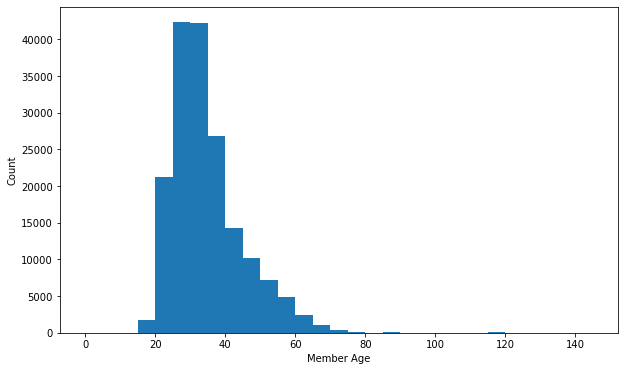

```python
# plot a distribution of age_member to visually examine the outliers

plt.figure(figsize=[10, 6])
bins = np.arange(0, clean_df['age_member'].max()+5, 5)
plt.hist(clean_df['age_member'], bins=bins);
plt.xlabel('Member Age');
plt.ylabel('Count');
```

> **observation**:From the plotted histogram,we can observe values greater than 80-120 years old which in my case will be outliers as it's not reasonable to have ridersbeyond age 80. Some might be able to ride but they are only a few cases. So I will concentrate on rider below or equal to 80years old.

```python
#filter out outlier ages which are those that a greater than 80 years
clean_df = clean_df.query('age_member <= 80')
clean_df.sample(15)
```

|  | duration_sec | start_time | end_time | start_station_id | start_station_name | start_station_latitude | start_station_longitude | end_station_id | end_station_name | end_station_latitude | ... | user_type | member_birth_year | member_gender | bike_share_for_all_trip | duration_minute | start_date | start_hour | start_dayofweek | start_month | age_member |
| --- | --- | --- | --- | --- | --- | --- | --- | --- | --- | --- | --- | --- | --- | --- | --- | --- | --- | --- | --- | --- | --- |
| 161478 | 417 | 2019-02-05 14:48:30.815 | 2019-02-05 14:55:28.385 | 849 | Haste St at Telegraph Ave | 37.866043 | -122.258804 | 849 | Berkeley Civic Center | 37.869060 | ... | Subscriber | 1999 | Male | No | 6.950000 | 2019-02-05 | 14 | Tuesday | February | 20 |
| 118872 | 657 | 2019-02-11 18:21:53.208 | 2019-02-11 18:32:50.546 | 2302 | San Jose Diridon Station | 37.329732 | -121.901782 | 2302 | San Salvador St at 9th St | 37.333955 | ... | Subscriber | 1983 | Male | No | 10.950000 | 2019-02-11 | 18 | Monday | February | 36 |
| 107065 | 854 | 2019-02-13 16:56:39.976 | 2019-02-13 17:10:53.985 | 5146 | Telegraph Ave at 27th St | 37.816073 | -122.267886 | 5146 | 14th St at Mandela Pkwy | 37.810743 | ... | Subscriber | 1994 | Female | No | 14.233333 | 2019-02-13 | 16 | Wednesday | February | 25 |
| 89777 | 274 | 2019-02-16 14:42:21.723 | 2019-02-16 14:46:56.316 | 3815 | 5th St at Virginia St | 37.325998 | -121.877120 | 3815 | San Salvador St at 9th St | 37.333955 | ... | Subscriber | 1995 | Male | Yes | 4.566667 | 2019-02-16 | 14 | Saturday | February | 24 |
| 82312 | 2162 | 2019-02-18 10:12:31.780 | 2019-02-18 10:48:34.131 | 357 | Folsom St at 15th St | 37.767037 | -122.415442 | 357 | The Embarcadero at Sansome St | 37.804770 | ... | Subscriber | 1987 | Male | No | 36.033333 | 2019-02-18 | 10 | Monday | February | 32 |
| 41109 | 483 | 2019-02-22 19:01:14.624 | 2019-02-22 19:09:17.713 | 6471 | The Embarcadero at Bryant St | 37.787168 | -122.388098 | 6471 | San Francisco Caltrain (Townsend St at 4th St) | 37.776598 | ... | Subscriber | 1970 | Male | No | 8.050000 | 2019-02-22 | 19 | Friday | February | 49 |
| 182926 | 278 | 2019-02-01 07:35:47.206 | 2019-02-01 07:40:25.357 | 5440 | Mission Playground | 37.759210 | -122.421339 | 5440 | Valencia St at Cesar Chavez St | 37.747998 | ... | Subscriber | 1989 | Male | No | 4.633333 | 2019-02-01 | 7 | Friday | February | 30 |
| 124845 | 693 | 2019-02-11 08:09:37.000 | 2019-02-11 08:21:10.908 | 5534 | The Embarcadero at Sansome St | 37.804770 | -122.403234 | 5534 | 3rd St at Townsend St | 37.778742 | ... | Subscriber | 1973 | Male | No | 11.550000 | 2019-02-11 | 8 | Monday | February | 46 |
| 94025 | 344 | 2019-02-15 17:05:31.047 | 2019-02-15 17:11:15.201 | 4806 | 3rd St at Townsend St | 37.778742 | -122.392741 | 4806 | Rhode Island St at 17th St | 37.764478 | ... | Subscriber | 1987 | Male | No | 5.733333 | 2019-02-15 | 17 | Friday | February | 32 |
| 77868 | 2081 | 2019-02-18 22:09:21.287 | 2019-02-18 22:44:02.514 | 6573 | The Embarcadero at Sansome St | 37.804770 | -122.403234 | 6573 | Davis St at Jackson St | 37.797280 | ... | Customer | 1999 | Male | No | 34.683333 | 2019-02-18 | 22 | Monday | February | 20 |
| 40067 | 799 | 2019-02-22 22:28:49.665 | 2019-02-22 22:42:09.579 | 4719 | San Francisco Public Library (Grove St at Hyde... | 37.778768 | -122.415929 | 4719 | Laguna St at Hayes St | 37.776435 | ... | Subscriber | 1983 | Male | Yes | 13.316667 | 2019-02-22 | 22 | Friday | February | 36 |
| 100035 | 1814 | 2019-02-14 18:24:24.849 | 2019-02-14 18:54:38.957 | 204 | 4th St at Mission Bay Blvd S | 37.770407 | -122.391198 | 204 | Howard St at Mary St | 37.781010 | ... | Subscriber | 1986 | Other | Yes | 30.233333 | 2019-02-14 | 18 | Thursday | February | 33 |
| 115945 | 1216 | 2019-02-12 08:03:56.578 | 2019-02-12 08:24:12.872 | 4373 | Williams Ave at 3rd St | 37.729279 | -122.392896 | 4373 | 4th St at Mission Bay Blvd S | 37.770407 | ... | Subscriber | 1996 | Female | No | 20.266667 | 2019-02-12 | 8 | Tuesday | February | 23 |
| 30081 | 395 | 2019-02-24 22:14:57.158 | 2019-02-24 22:21:32.240 | 5628 | College Ave at Alcatraz Ave | 37.851376 | -122.252523 | 5628 | Bancroft Way at College Ave | 37.869360 | ... | Subscriber | 1992 | Male | No | 6.583333 | 2019-02-24 | 22 | Sunday | February | 27 |
| 150973 | 247 | 2019-02-06 17:45:21.870 | 2019-02-06 17:49:29.047 | 3579 | Division St at Potrero Ave | 37.769218 | -122.407646 | 3579 | 8th St at Ringold St | 37.774520 | ... | Subscriber | 1982 | Male | No | 4.116667 | 2019-02-06 | 17 | Wednesday | February | 37 |

15 rows × 22 columns

### **Most riders are around which age bracket?**

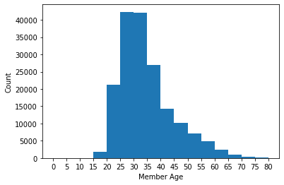

```python
# plot a distribution of age_member to visually examine if outliers have been filtered out
bins = np.arange(0, clean_df['age_member'].max()+5, 5)
plt.hist(data=clean_df, x='age_member', bins=bins);
plt.xticks(bins, bins);
plt.xlabel('Member Age');
plt.ylabel('Count');
```

> **Observation**: After filtering out the outliers i.e ages >=80,I visualized the members age, most member's age were around 25-40 years olds

## Hourly, daily and monthly Visuals

### When are most trips taken in terms of time of day?

```python
clean_df.info(null_counts = True)
```

```
<class 'pandas.core.frame.DataFrame'>
Int64Index: 174760 entries, 0 to 183411
Data columns (total 22 columns):
 #   Column                   Non-Null Count   Dtype
---  ------                   --------------   -----
 0   duration_sec             174760 non-null  int64
 1   start_time               174760 non-null  datetime64[ns]
 2   end_time                 174760 non-null  datetime64[ns]
 3   start_station_id         174760 non-null  object
 4   start_station_name       174760 non-null  object
 5   start_station_latitude   174760 non-null  float64
 6   start_station_longitude  174760 non-null  float64
 7   end_station_id           174760 non-null  object
 8   end_station_name         174760 non-null  object
 9   end_station_latitude     174760 non-null  float64
 10  end_station_longitude    174760 non-null  float64
 11  bike_id                  174760 non-null  object
 12  user_type                174760 non-null  category
 13  member_birth_year        174760 non-null  int32
 14  member_gender            174760 non-null  category
 15  bike_share_for_all_trip  174760 non-null  category
 16  duration_minute          174760 non-null  float64
 17  start_date               174760 non-null  object
 18  start_hour               174760 non-null  int64
 19  start_dayofweek          174760 non-null  object
 20  start_month              174760 non-null  object
 21  age_member               174760 non-null  int32
dtypes: category(3), datetime64[ns](2), float64(5), int32(2), int64(2), object(8)
memory usage: 25.8+ MB
```

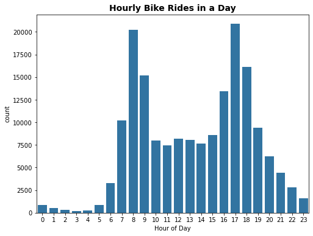

```python
# trip distribution over day hours
plt.figure(figsize=(8, 6))
#start_hour = [00,]
base_color = sb.color_palette()[0]
sb.countplot(data=clean_df, x='start_hour', color=base_color)
plt.title('Hourly Bike Rides in a Day', fontsize=14, fontweight='bold')
plt.xlabel('Hour of Day');
```

**Observation**: The distribution shows a `bimodal` distributions with two peaks oe occuring at at `08 hours(8am)` and another one at `17 hours(5pm)`. There is higher usage of bikes at around 7am-9am and 4pm-7pm. which can be an indication of people riding to work and back home in the evening after work.

### When are most trips taken in terms day of the week,

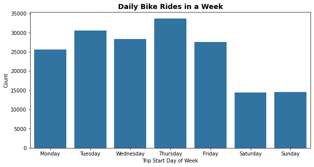

```python
plt.figure(figsize=(10, 5))
weekday = ['Monday', 'Tuesday', 'Wednesday', 'Thursday', 'Friday', 'Saturday', 'Sunday']
weekdaycat = pd.api.types.CategoricalDtype(ordered=True, categories=weekday)
clean_df['start_dayofweek'] = clean_df['start_dayofweek'].astype(weekdaycat)

sb.countplot(data=clean_df, x = 'start_dayofweek', color=base_color);
plt.title('Daily Bike Rides in a Week', fontsize=14, fontweight='bold')
plt.xlabel('Trip Start Day of Week');
plt.ylabel('Count');
```

**Observation**: Bikes are using less on weekends and more on Weekdays. Thursdays shows the highest usage of bikes.

### When are most trips taken in terms of month of the year?

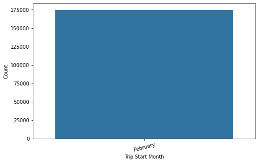

```python
plt.figure(figsize=(8, 5))

sb.countplot(data=clean_df, x='start_month', color=base_color);
plt.xticks(rotation=15);
plt.xlabel('Trip Start Month');
plt.ylabel('Count');
```

**Observation**: The visualization shows start_month dataset covers only one month, the month of February and no data for other months.

## Duration of a trip

### How long does the average trip take?

```python
clean_df['duration_minute'].describe()
```

```
count    174760.000000
mean         11.738494
std          27.383861
min           1.016667
25%           5.383333
50%           8.516667
75%          13.150000
max        1409.133333
Name: duration_minute, dtype: float64
```

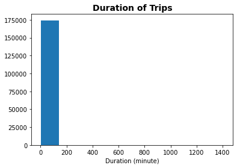

```python
# histogram plot displaying duration_sec
plt.hist(data=clean_df, x='duration_minute')
plt.xlabel('Duration (minute)');
plt.title('Duration of Trips', fontsize=14, fontweight='bold')
```

-`Observation` The duration of trips is positively skewed to the right.Distribution is skewed to the right with a maximum duration as 1400 minutes, duration of most trips is with 200 minutes

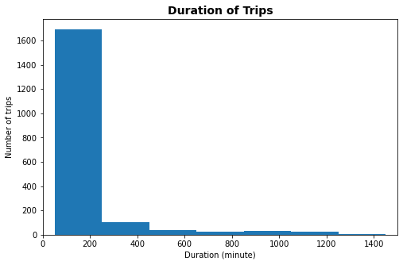

```python
# Adjust the bins and set limit to x
binsize = 200
plt.figure(figsize=[8, 5])
bin_edges = np.arange(50, clean_df['duration_minute'].max()+binsize, binsize)
plt.hist(data=clean_df, x='duration_minute', bins=bin_edges)
plt.xlabel('Duration (minute)')
plt.ylabel('Number of trips')
plt.xlim(0, 1500)  # set up a limit due to the outliers
plt.title('Duration of Trips', fontsize=14, fontweight='bold')
plt.show()
```

-`Oservation` The distribution is skewed to the right with a maximum duration as 1400 minutes, duration of most trips is with 200 minutes.It was a little surprising to see the duration spanning almost 24 hours.I'm going to zoom in to the most cases for a closer picture of what the distribution is like.

```python
clean_df['duration_minute'].describe(percentiles=[.99])
```

```
count    174760.000000
mean         11.738494
std          27.383861
min           1.016667
50%           8.516667
99%          52.947000
max        1409.133333
Name: duration_minute, dtype: float64
```

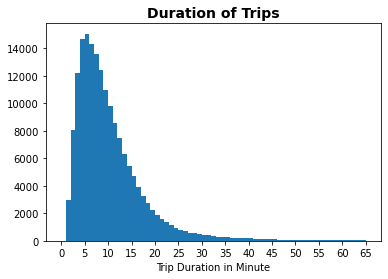

```python
#change been sizes to show trip duration distribution
bins = np.arange(0, 66, 1)
ticks = np.arange(0, 66, 5)
plt.hist(data=clean_df, x='duration_minute', bins=bins);
plt.xticks(ticks, ticks);
plt.title('Duration of Trips', fontsize=14, fontweight='bold')
plt.xlabel('Trip Duration in Minute');
```

`Observation`

- The distribution of duration is skewed to the right, duration of most trips seem to ranging from 5-15 minutes
- Looks like 99% of the Trips were less than 1 our long. I'll go ahead and remove outliers to enable focusing on most common duration of trips.

```python
#filter out Trip duration >66 minutes
clean_df= clean_df.query('duration_minute <= 66')
clean_df.info(null_counts=True)
```

```
<class 'pandas.core.frame.DataFrame'>
Int64Index: 173543 entries, 4 to 183411
Data columns (total 22 columns):
 #   Column                   Non-Null Count   Dtype
---  ------                   --------------   -----
 0   duration_sec             173543 non-null  int64
 1   start_time               173543 non-null  datetime64[ns]
 2   end_time                 173543 non-null  datetime64[ns]
 3   start_station_id         173543 non-null  object
 4   start_station_name       173543 non-null  object
 5   start_station_latitude   173543 non-null  float64
 6   start_station_longitude  173543 non-null  float64
 7   end_station_id           173543 non-null  object
 8   end_station_name         173543 non-null  object
 9   end_station_latitude     173543 non-null  float64
 10  end_station_longitude    173543 non-null  float64
 11  bike_id                  173543 non-null  object
 12  user_type                173543 non-null  category
 13  member_birth_year        173543 non-null  int32
 14  member_gender            173543 non-null  category
 15  bike_share_for_all_trip  173543 non-null  category
 16  duration_minute          173543 non-null  float64
 17  start_date               173543 non-null  object
 18  start_hour               173543 non-null  int64
 19  start_dayofweek          173543 non-null  category
 20  start_month              173543 non-null  object
 21  age_member               173543 non-null  int32
dtypes: category(4), datetime64[ns](2), float64(5), int32(2), int64(2), object(7)
memory usage: 24.5+ MB
```

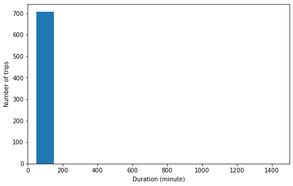

```python
# Adjust the bins and set limit to x
binsize = 100
plt.figure(figsize=[8, 5])
bin_edges = np.arange(50, clean_df['duration_minute'].max()+binsize, binsize)
plt.hist(data=clean_df, x='duration_minute', bins=bin_edges)
plt.xlabel('Duration (minute)')
plt.ylabel('Number of trips')
plt.xlim(0, 1500)  # set up a limit due to the outliers
plt.show()
```

- `observation` From the above plot, the outliers have been removed.

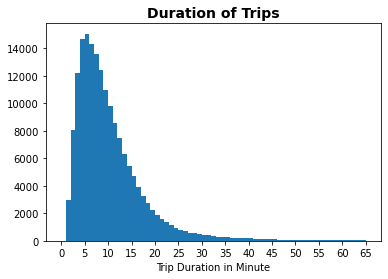

```python
#plot duration of trips after removing outliers
bins = np.arange(0, 66, 1)
ticks = np.arange(0, 66, 5)
plt.hist(data=clean_df, x='duration_minute', bins=bins);
plt.xticks(ticks, ticks);
plt.title('Duration of Trips', fontsize=14, fontweight='bold')
plt.xlabel('Trip Duration in Minute');
```

- `Observation`: a plot after the removal of outliers and most trips are 5-10 minutes.

```python
#show outliers have been removed
clean_df['duration_minute'].describe()
```

```
count    173543.000000
mean         10.362841
std           7.570748
min           1.016667
25%           5.366667
50%           8.466667
75%          13.016667
max          66.000000
Name: duration_minute, dtype: float64
```

-`Observation` Maximum tripduration is now 66 minutes and minimum trip duration is 1 minute. The average Trip took 10 minutes. Approximately half of the riders took 8 minutes.

## Users and use of bike_share

### Which riders take more trips? Subscribers or Customers?

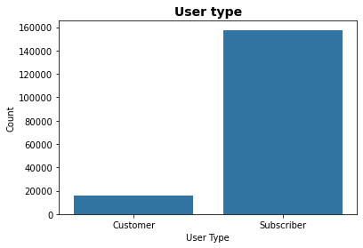

```python
#plot distribution of user_type
sb.countplot(data=clean_df, x='user_type', color=base_color);
plt.title('User type', fontsize=14, fontweight='bold')
plt.xlabel('User Type');
plt.ylabel('Count');
```

`Observation`: From the observation, the subscribers took more trips as compared to customers.

### In terms of member_gender, which gender takes more trips?

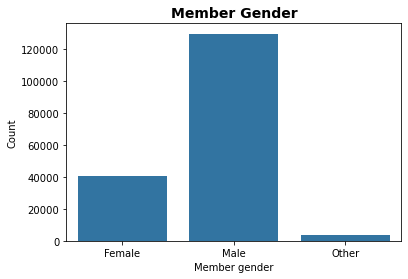

```python
#plot distribution of user_type
sb.countplot(data=clean_df, x='member_gender', color=base_color);
plt.title('Member Gender', fontsize=14, fontweight='bold')
plt.xlabel('Member gender');
plt.ylabel('Count');
```

`Observation`: The males took more trips followed by females and proportion of trips taken by others is the least.

### Is usage of bike_share trip common?

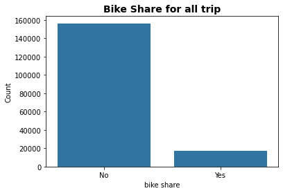

```python
#plot distribution of user_type
sb.countplot(data=clean_df, x='bike_share_for_all_trip', color=base_color);
plt.title('Bike Share for all trip', fontsize=14, fontweight='bold')
plt.xlabel('bike share');
plt.ylabel('Count');
```

`Observation`: Majority idid not use bike Share for all trips

### Of the features you investigated, were there any unusual distributions? Did you perform any operations on the data to tidy, adjust, or change the form of the data? If so, why did you do this?

- I had to remove outliers in the trip durations since some trips tok 20 plus hours which is impossible. I also removed outliers in the member's age since some were over 80 years old and it's unlikely from them to be riding a bike at that age.
- Birth year is converted by substracting the year from current year so this gives us a distibution for age, this action is performed as age gives a better perception regarding trip duration dependency.
- In order to find out usage pattern in terms of time of day and day of the week, I had to use start_time and convert it to start_date, start_hour, start_dayofweek and start_month and put into separate columns for analysis since this data is not provided separately.
- I prefered converting duration to minutes for easy translation

## Bivariate Exploration

> This section investigates the relationships between pairs of variables in the data.

Make sure the variables that you cover here have been introduced in some fashion in the previous section (univariate exploration).

```python
# save the clean data to a .csv file

clean_df.to_csv('fordgobike_trips_2019_clean.csv', index=False)
```

```python
#look at features in the dataset
clean_df.dtypes
```

```
duration_sec                        int64
start_time                 datetime64[ns]
end_time                   datetime64[ns]
start_station_id                   object
start_station_name                 object
start_station_latitude            float64
start_station_longitude           float64
end_station_id                     object
end_station_name                   object
end_station_latitude              float64
end_station_longitude             float64
bike_id                            object
user_type                        category
member_birth_year                   int32
member_gender                    category
bike_share_for_all_trip          category
duration_minute                   float64
start_date                         object
start_hour                          int64
start_dayofweek                  category
start_month                        object
age_member                          int32
dtype: object
```

```python
#chnage start_dayof week and start_month data type
clean_df.start_dayofweek = clean_df.start_dayofweek.astype('str')
clean_df.start_month = clean_df.start_month.astype('str')
```

```python
clean_df.dtypes
```

```
duration_sec                        int64
start_time                 datetime64[ns]
end_time                   datetime64[ns]
start_station_id                   object
start_station_name                 object
start_station_latitude            float64
start_station_longitude           float64
end_station_id                     object
end_station_name                   object
end_station_latitude              float64
end_station_longitude             float64
bike_id                            object
user_type                        category
member_birth_year                   int32
member_gender                    category
bike_share_for_all_trip          category
duration_minute                   float64
start_date                         object
start_hour                          int64
start_dayofweek                    object
start_month                        object
age_member                          int32
dtype: object
```

## Effect of Trip Duration feauture on other features

### Duration vs Age

- I will use both correlation and a scatter plot

```python
numeric_vars = ['duration_minute', 'age_member']
```

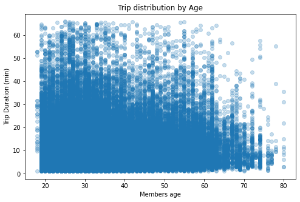

```python
# scatter charts showing distribution between age and trip duration
plt.figure(figsize=[8, 5])
plt.scatter(data=clean_df, x='age_member', y='duration_minute', alpha=0.25)
plt.title('Trip distribution by Age')
plt.xlabel('Members age')
plt.ylabel('Trip Duration (min)')
plt.show()
```

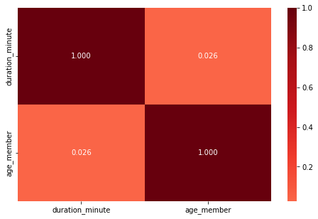

```python
# heatmap to show relationship between duration of trip and age
plt.figure(figsize=[8, 5])
sb.heatmap(clean_df[numeric_vars].corr(), annot=True,fmt='.3f', cmap='Reds', center=0)
plt.show()
```

### Duration vs User_type

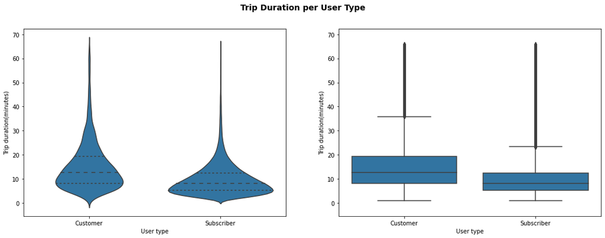

```python
# plot duration vs user type using violin plot and boxplot
fig = plt.figure(figsize=[18, 6])
base_color = sb.color_palette()[0]

# left plot: violin plot
plt.subplot(1, 2, 1)
ax1 = sb.violinplot(data=clean_df, x='user_type', y='duration_minute', color=base_color,inner='quartile')
plt.xlabel('User type')
plt.ylabel('Trip duration(minutes)')

# right plot: box plot
plt.subplot(1, 2, 2)
sb.boxplot(data=clean_df, x='user_type',y='duration_minute', color=base_color)
plt.xlabel('User type')
plt.ylabel('Trip duration(minutes)')
plt.ylim(ax1.get_ylim())  # set y-axis limits to be same as left plot
fig.suptitle('Trip Duration per User Type', fontsize=14, fontweight='bold')
plt.show()
```

[output not shown]

[figure not shown]

```python
#plot acerage trip duration based on user type
clean_df.groupby('user_type')['duration_sec'].mean().plot(kind='bar', figsize=(7, 5))
plt.title(' Average Trip Duration Based on User Type',fontsize=14, fontweight='bold')
plt.xlabel('User type')
plt.ylabel('Trip duration(minutes)')
plt.xticks(rotation=0)
```

- `Observation`: Even though the subscibers take more trip, the three plots show that the trip duration is longer in customers as compared to subscribers

### Duration vs Start_dayofweek

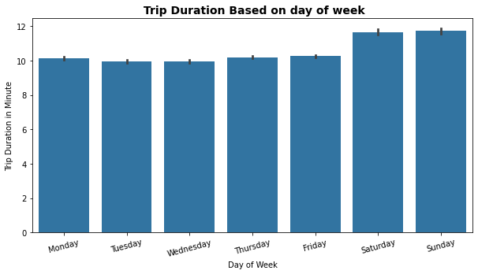

```python
plt.figure(figsize=(10, 5))
weekday = ['Monday', 'Tuesday', 'Wednesday', 'Thursday', 'Friday', 'Saturday', 'Sunday']
weekdaycat = pd.api.types.CategoricalDtype(ordered=True, categories=weekday)
clean_df['start_dayofweek'] = clean_df['start_dayofweek'].astype(weekdaycat)

#plot
sb.barplot(data=clean_df, x='start_dayofweek', y='duration_minute', color=base_color);
plt.title(' Trip Duration Based on day of week',fontsize=14, fontweight='bold')
plt.xlabel('Day of Week');
plt.ylabel('Trip Duration in Minute');
plt.xticks(rotation=15);
```

`Observation`: Trip durations is longer on weekends as compared to weekdays

### Duration vs Member_gender

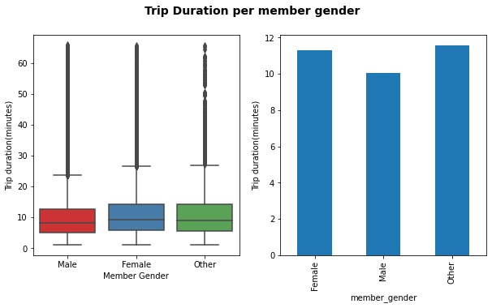

```python
# plot duration vs user type using violin plot and boxplot
fig = plt.figure(figsize=[20, 6])
base_color = sb.color_palette()[0]

# left plot: violin plot
plt.subplot(1, 2, 1)
ax1 = sb.boxplot(data=clean_df, x='member_gender', y='duration_minute', color=base_color, palette='Set1', order=['Male', 'Female', 'Other'])
plt.xlabel('Member Gender')
plt.ylabel('Trip duration(minutes)')

# right plot: box plot
plt.subplot(1, 2, 2)
clean_df.groupby('member_gender')['duration_minute'].mean().plot(kind='bar', figsize = [10,5])
plt.ylabel('Trip duration(minutes)')
fig.suptitle('Trip Duration per member gender', fontsize=14, fontweight='bold')
plt.show()
```

`Observation`: The boxplot and the graph shows that female and other gender have a slightly higher trip duration than males.

## What's the relationship between gender and user type

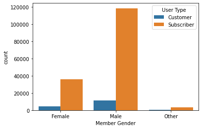

```python
#plot categorical variables gender and user type
# plot the relationship between user type and gender
sb.countplot(data=clean_df, x='member_gender', hue='user_type')
plt.xlabel('Member Gender')
plt.legend(title='User Type')
```

`Observation`: The number of male subscribers are more as compared tofemale and other genders.

## Hourly bike usage in number per user type

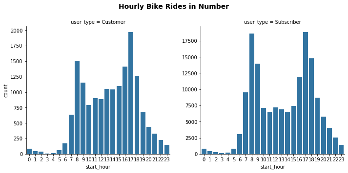

```python
# Use Facet & catplot to plot subscribers and customers
base_color = sb.color_palette()[0]
sb.catplot(data=clean_df, x='start_hour', col='user_type', kind='count', color=base_color, sharey=False)
plt.subplots_adjust(top=0.85)
plt.suptitle('Hourly Bike Rides in Number', fontsize=14, fontweight='bold');
```

`Observation`: Subscribers take most of their trips around 8-9am and 4-6pm, typical commute hours. There are less bike rides during 10am-3pm. For customers, 8am-6pm is the popular time period to rent the bike.

### Did you observe any interesting relationships between the other features (not the main feature(s) of interest)?

- The relationship between gender members and trip duration is a unique one as it shows that male had the lowest trip duration, you had expect female to have the lowest trip duration. I also found that among users, an actual customer is spending more time on a bike trip than subscribers., you had expect subscribers to ride for a longer time period.

## Multivariate Exploration

> In this section, I will create plots of three or more variables to investigate the data.
- I will investigate the relationship between gender, trip duration an age. I will also invesitigate the relationship between day of week, user_type, duration in minutes and other variables.

## What is the relationship between gender, age and Trip duration

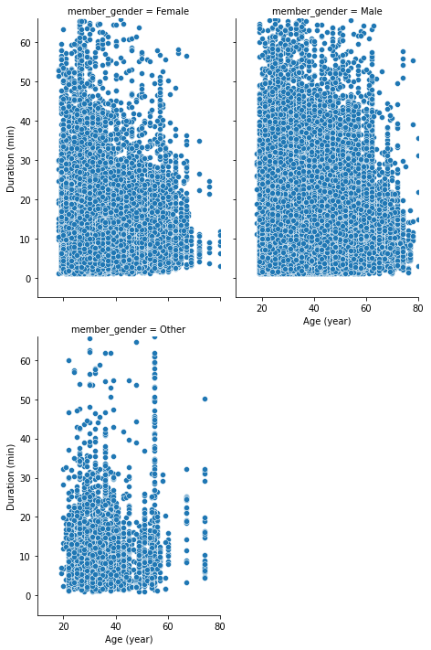

```python
plt.figure(figsize=[15, 10])
g = sb.FacetGrid(data=clean_df, col='member_gender', col_wrap=2,height=5, aspect=0.65, xlim=[10, 80], ylim=[-5, 66])
g.map_dataframe(sb.scatterplot, 'age_member', 'duration_minute')
g.set_axis_labels('Age (year)', 'Duration (min)')
g.add_legend()
plt.show();
```

## How does the average trip duration vary in weekdays between customers and subscribers?

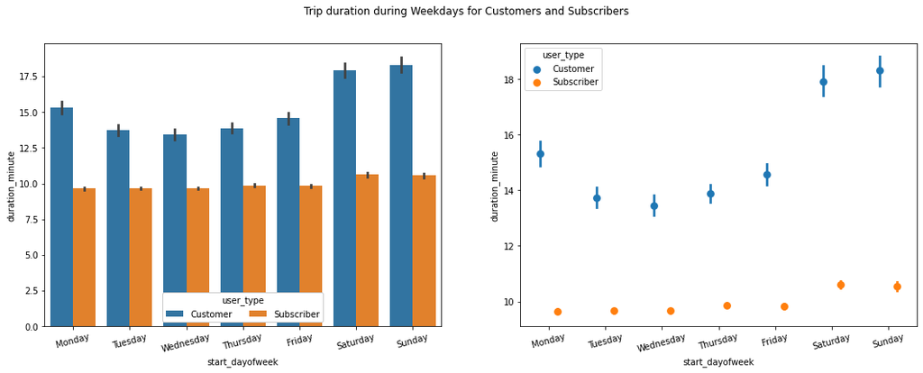

```python
fig = plt.figure(figsize=[18, 6])
plt.suptitle('Trip duration during Weekdays for Customers and Subscribers')
plt.subplot(1, 2, 1)
ax1 = sb.barplot(data = clean_df, x = 'start_dayofweek', y = 'duration_minute', hue = 'user_type')
ax1.legend(loc = 8, ncol = 3, framealpha = 1, title = 'user_type')
plt.xticks(rotation=15);

plt.subplot(1, 2, 2)
sb.pointplot(data = clean_df, x = 'start_dayofweek', y = 'duration_minute', hue = 'user_type',
                  dodge = 0.3, linestyles = "")
plt.xticks(rotation=15);
```

`Observation`:From the above plot, it shows that subscribers take much shorter trips compared to customers on each day of the week. Both user types have an obvious increase of trip duration on Saturdays and Sundays over weekdays, especially for customers.As for weekdays, customers usage of bikes is quite high on Monday. Subscribers usage seems to be more efficient than customers overall and maintained a very consistent average duration Monday through Friday. Subsciber usage is dependable for profit gain as compared to customers usage.

## How does the hourly usage vary during weekdays for customers and subscribers?

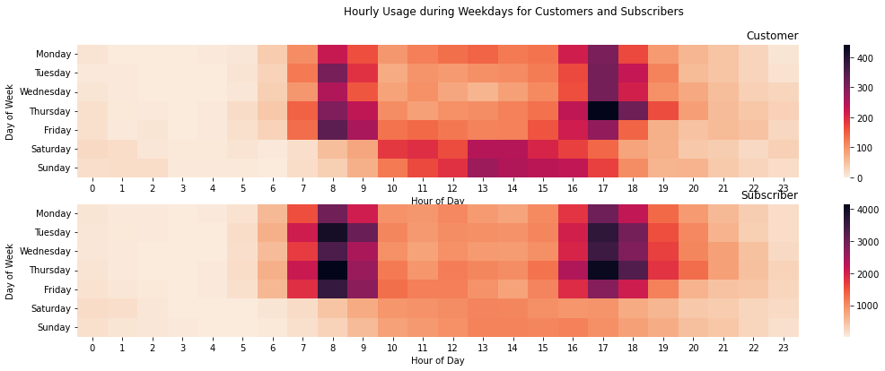

```python
fig = plt.figure(figsize=[18, 6])
plt.suptitle('Hourly Usage during Weekdays for Customers and Subscribers')

plt.subplot(2, 1, 1)
customers = clean_df.query('user_type == "Customer"')
ct_counts = customers.groupby(['start_dayofweek', 'start_hour']).size()
ct_counts = ct_counts.reset_index(name='count')
ct_counts = ct_counts.pivot(index='start_dayofweek', columns='start_hour', values='count')
sb.heatmap(ct_counts, cmap='rocket_r');
plt.title('Customer', loc='right');
plt.xlabel('Hour of Day');
plt.ylabel('Day of Week');

plt.subplot(2, 1, 2)
subscribers = clean_df.query('user_type == "Subscriber"')
st_counts = subscribers.groupby(['start_dayofweek', 'start_hour']).size()
st_counts = st_counts.reset_index(name='count')
st_counts = st_counts.pivot(index='start_dayofweek', columns='start_hour', values='count')
sb.heatmap(st_counts, cmap='rocket_r');
plt.title('Subscriber', loc='right');
plt.xlabel('Hour of Day');
plt.ylabel('Day of Week');
```

`Observation`: From the above heatmap, it shows the different patterns depending on the user type. The subscribers seem to use the bikes more on weekdays and mostly during 8-9am and 5-6pm. This shows that they are used for commuting to work. As for customers, they have a greater usage of bike more on weekends as compared to subscribers and ride as from 10am-5pm. During the weekdays, the customers start using bikes heavily at 8am-9am and 5-6pm.

### Were there any interesting or surprising interactions between features?

- The interactions between features are all supplementing each other and quite make sense when looked at combined varibales.
- There's no big surprise observed. The usage habit difference between male and female is not that much or obvious throughout the exploration, which could be related to the imbalanced number of female riders/records compared to male ones. It'd be interesting to see how male and female use the system differently if there were more female data.

## References

- https://stackoverflow.com/questions/37625334/python-pandas-convert-month-int-to-month-name
- https://www.kaggle.com/code/chirag02/ford-gobike-data-analysis
- https://seaborn.pydata.org/generated/seaborn.FacetGrid.html
- Udacity classroom tutorials, data analyst nanodegree
- https://datagy.io/pandas-extract-date-from-datetime/
- https://stackoverflow.com/questions/25129144/pandas-return-hour-from-datetime-column-directly